# Uber Analytics Project

# Part 1

# Intro

### EDA

Exploratory Data Analysis (EDA) is the process of **examining and visualizing a dataset** to understand its main characteristics before applying statistical models or machine learning. It involves summarizing data, identifying missing values or outliers, checking variable distributions, and uncovering relationships or patterns. In R, EDA is typically done using functions such as `summary()`, `str()`, and visualization tools like `ggplot2` to create histograms, bar charts, and scatterplots.

### Research Question

The goal of this project is to explore the **Uber NCR Ride Bookings** dataset to understand **ride performance, booking patterns, and customer-driver behaviors**.

My research question is:

## What factors influence customer satisfaction in Uber’s 2024 operations?

This question helps identify service issues such as high cancellation rates, poor driver ratings, or inefficient routes.

### Data Wrangling process?

  These steps ensure that the dataset is consistent and ready for accurate analysis.

### Variables of Interest

The dataset `ncr_ride_bookings` contains around **150,000 rows** (individual ride records) and **21 columns** (variables).

Key variables of interest include:

- **Booking.Status** – shows whether rides were *Completed*, *Cancelled*, or *Incomplete*
- **Vehicle.Type** – identifies types of vehicles used (e.g., eBike, Sedan, Auto, Bike)
- **Booking.Value** – represents the total fare for the ride
- **Ride.Distance** – measures trip distance
- **Driver.Ratings** and **Customer.Rating** – measure satisfaction and performance

By analyzing these variables, we can identify **patterns in ride success rates, cancellation behavior, and rating trends** across different vehicle types and payment methods.

# Set Up

Download all required libraries

## Load Data

Load data into dataframe

```r
# Load CSV from the same folder as the .qmd
ncr_ride_bookings <- read.csv("ncr_ride_bookings.csv", stringsAsFactors = FALSE)
df <- ncr_ride_bookings

# Quick check
glimpse(df)
```

```
Rows: 150,000
Columns: 21
$ Date                              <chr> "3/23/24", "11/29/24", "8/23/24", "1…
$ Time                              <chr> "12:29:38", "18:01:39", "8:56:10", "…
$ Booking.ID                        <chr> "\"CNR5884300\"", "\"CNR1326809\"", …
$ Booking.Status                    <chr> "No Driver Found", "Incomplete", "Co…
$ Customer.ID                       <chr> "\"CID1982111\"", "\"CID4604802\"", …
$ Vehicle.Type                      <chr> "eBike", "Go Sedan", "Auto", "Premie…
$ Pickup.Location                   <chr> "Palam Vihar", "Shastri Nagar", "Kha…
$ Drop.Location                     <chr> "Jhilmil", "Gurgaon Sector 56", "Mal…
$ Avg.VTAT                          <chr> "null", "4.9", "13.4", "13.1", "5.3"…
$ Avg.CTAT                          <chr> "null", "14", "25.8", "28.5", "19.6"…
$ Cancelled.Rides.by.Customer       <chr> "null", "null", "null", "null", "nul…
$ Reason.for.cancelling.by.Customer <chr> "null", "null", "null", "null", "nul…
$ Cancelled.Rides.by.Driver         <chr> "null", "null", "null", "null", "nul…
$ Driver.Cancellation.Reason        <chr> "null", "null", "null", "null", "nul…
$ Incomplete.Rides                  <chr> "null", "1", "null", "null", "null",…
$ Incomplete.Rides.Reason           <chr> "null", "Vehicle Breakdown", "null",…
$ Booking.Value                     <chr> "null", "237", "627", "416", "737", …
$ Ride.Distance                     <chr> "null", "5.73", "13.58", "34.02", "4…
$ Driver.Ratings                    <chr> "null", "null", "4.9", "4.6", "4.1",…
$ Customer.Rating                   <chr> "null", "null", "4.9", "5", "4.3", "…
$ Payment.Method                    <chr> "null", "UPI", "Debit Card", "UPI", …
```

```r
head(df)
```

```
      Date     Time   Booking.ID  Booking.Status  Customer.ID  Vehicle.Type
1  3/23/24 12:29:38 "CNR5884300" No Driver Found "CID1982111"         eBike
2 11/29/24 18:01:39 "CNR1326809"      Incomplete "CID4604802"      Go Sedan
3  8/23/24  8:56:10 "CNR8494506"       Completed "CID9202816"          Auto
4 10/21/24 17:17:25 "CNR8906825"       Completed "CID2610914" Premier Sedan
5  9/16/24 22:08:00 "CNR1950162"       Completed "CID9933542"          Bike
6   2/6/24  9:44:56 "CNR4096693"       Completed "CID4670564"          Auto
      Pickup.Location     Drop.Location Avg.VTAT Avg.CTAT
1         Palam Vihar           Jhilmil     null     null
2       Shastri Nagar Gurgaon Sector 56      4.9       14
3             Khandsa     Malviya Nagar     13.4     25.8
4 Central Secretariat          Inderlok     13.1     28.5
5    Ghitorni Village       Khan Market      5.3     19.6
6               AIIMS       Narsinghpur      5.1     18.1
  Cancelled.Rides.by.Customer Reason.for.cancelling.by.Customer
```

[output cut: 27 more lines]

## Inspect and clean data

Replace null with “NA”

```r
# Replace "null" with "NA"
df <- as.data.frame(lapply(df, function(x) {
  # Skip conversion for Date columns
  if (inherits(x, "Date")) return(x)

  # Convert factors to characters first
  if (is.factor(x)) x <- as.character(x)

  # Replace "null" or empty strings with NA
  x[x == "null" | x == ""] <- NA

  return(x)
}))

# Verify
head(df)
```

```
      Date     Time   Booking.ID  Booking.Status  Customer.ID  Vehicle.Type
1  3/23/24 12:29:38 "CNR5884300" No Driver Found "CID1982111"         eBike
2 11/29/24 18:01:39 "CNR1326809"      Incomplete "CID4604802"      Go Sedan
3  8/23/24  8:56:10 "CNR8494506"       Completed "CID9202816"          Auto
4 10/21/24 17:17:25 "CNR8906825"       Completed "CID2610914" Premier Sedan
5  9/16/24 22:08:00 "CNR1950162"       Completed "CID9933542"          Bike
6   2/6/24  9:44:56 "CNR4096693"       Completed "CID4670564"          Auto
      Pickup.Location     Drop.Location Avg.VTAT Avg.CTAT
1         Palam Vihar           Jhilmil     <NA>     <NA>
2       Shastri Nagar Gurgaon Sector 56      4.9       14
3             Khandsa     Malviya Nagar     13.4     25.8
4 Central Secretariat          Inderlok     13.1     28.5
5    Ghitorni Village       Khan Market      5.3     19.6
6               AIIMS       Narsinghpur      5.1     18.1
  Cancelled.Rides.by.Customer Reason.for.cancelling.by.Customer
```

[output cut: 27 more lines]

```r
colSums(is.na(df))
```

```
                             Date                              Time
                                0                                 0
                       Booking.ID                    Booking.Status
                                0                                 0
                      Customer.ID                      Vehicle.Type
                                0                                 0
                  Pickup.Location                     Drop.Location
                                0                                 0
                         Avg.VTAT                          Avg.CTAT
                            10500                             48000
      Cancelled.Rides.by.Customer Reason.for.cancelling.by.Customer
                           139500                            139500
        Cancelled.Rides.by.Driver        Driver.Cancellation.Reason
                           123000                            123000
                 Incomplete.Rides           Incomplete.Rides.Reason
                           141000                            141000
                    Booking.Value                     Ride.Distance
                            48000                             48000
                   Driver.Ratings                   Customer.Rating
                            57000                             57000
                   Payment.Method
                            48000
```

## Convert Dates

```r
# Check dates
head(df$Date)
```

```
[1] "3/23/24"  "11/29/24" "8/23/24"  "10/21/24" "9/16/24"  "2/6/24"
```

```r
# Convert Dates
df$Date <- as.Date(df$Date, format = "%Y-%m-%d")

# Confirm it Worked
str(df$Date)
```

```
 Date[1:150000], format: NA NA NA NA NA NA NA NA NA NA NA NA NA NA NA NA NA NA NA NA NA NA NA ...
```

# Part 2

## Data Summary

Show Information about variables, including length, class, and number of missing values

```r
# Basic summary
summary(df)
```

```
      Date            Time            Booking.ID        Booking.Status
 Min.   :NA       Length:150000      Length:150000      Length:150000
 1st Qu.:NA       Class :character   Class :character   Class :character
 Median :NA       Mode  :character   Mode  :character   Mode  :character
 Mean   :NaN
 3rd Qu.:NA
 Max.   :NA
 NA's   :150000
 Customer.ID        Vehicle.Type       Pickup.Location    Drop.Location
 Length:150000      Length:150000      Length:150000      Length:150000
 Class :character   Class :character   Class :character   Class :character
 Mode  :character   Mode  :character   Mode  :character   Mode  :character




   Avg.VTAT           Avg.CTAT         Cancelled.Rides.by.Customer
 Length:150000      Length:150000      Length:150000
 Class :character   Class :character   Class :character
 Mode  :character   Mode  :character   Mode  :character




 Reason.for.cancelling.by.Customer Cancelled.Rides.by.Driver
 Length:150000                     Length:150000
 Class :character                  Class :character
 Mode  :character                  Mode  :character




 Driver.Cancellation.Reason Incomplete.Rides   Incomplete.Rides.Reason
 Length:150000              Length:150000      Length:150000
 Class :character           Class :character   Class :character
 Mode  :character           Mode  :character   Mode  :character




 Booking.Value      Ride.Distance      Driver.Ratings     Customer.Rating
 Length:150000      Length:150000      Length:150000      Length:150000
 Class :character   Class :character   Class :character   Class :character
 Mode  :character   Mode  :character   Mode  :character   Mode  :character




 Payment.Method
 Length:150000
 Class :character
 Mode  :character
```

```r
# Missing values per column
colSums(is.na(df))
```

```
                             Date                              Time
                           150000                                 0
                       Booking.ID                    Booking.Status
                                0                                 0
                      Customer.ID                      Vehicle.Type
                                0                                 0
                  Pickup.Location                     Drop.Location
                                0                                 0
                         Avg.VTAT                          Avg.CTAT
                            10500                             48000
      Cancelled.Rides.by.Customer Reason.for.cancelling.by.Customer
                           139500                            139500
        Cancelled.Rides.by.Driver        Driver.Cancellation.Reason
                           123000                            123000
                 Incomplete.Rides           Incomplete.Rides.Reason
                           141000                            141000
                    Booking.Value                     Ride.Distance
                            48000                             48000
                   Driver.Ratings                   Customer.Rating
                            57000                             57000
                   Payment.Method
                            48000
```

## Describe

Removes NA by default

```r
library(psych)
describe(df)
```

```
                                   vars      n     mean       sd  median
Date                                  1      0      NaN       NA      NA
Time*                                 2 150000 30444.99 17307.50 29572.5
Booking.ID*                           3 150000 74389.68 42945.54 74403.5
Booking.Status*                       4 150000     2.88     0.89     3.0
Customer.ID*                          5 150000 74408.02 42947.74 74422.5
Vehicle.Type*                         6 150000     3.39     1.86     4.0
Pickup.Location*                      7 150000    88.50    50.86    88.0
Drop.Location*                        8 150000    88.57    50.76    89.0
Avg.VTAT*                             9 139500   102.37    59.54   123.0
Avg.CTAT*                            10 102000   192.50    89.03   189.0
Cancelled.Rides.by.Customer*         11  10500     1.00     0.00     1.0
Reason.for.cancelling.by.Customer*   12  10500     3.23     1.32     3.0
Cancelled.Rides.by.Driver*           13  27000     1.00     0.00     1.0
Driver.Cancellation.Reason*          14  27000     2.50     1.12     2.0
Incomplete.Rides*                    15   9000     1.00     0.00     1.0
Incomplete.Rides.Reason*             16   9000     2.00     0.82     2.0
Booking.Value*                       17 102000  1655.35   701.27  1907.0
Ride.Distance*                       18 102000  2450.56  1437.26  2421.0
Driver.Ratings*                      19  93000    13.31     4.37    14.0
Customer.Rating*                     20  93000    15.05     4.38    16.0
Payment.Method*                      21 102000     3.42     1.68     4.0
                                    trimmed      mad min    max  range  skew
Date                                    NaN       NA Inf   -Inf   -Inf    NA
Time*                              30087.56 19442.82   1  62910  62909  0.16
Booking.ID*                        74390.19 55143.08   1 148767 148766  0.00
Booking.Status*                        2.85     0.00   1      5      4  0.24
Customer.ID*                       74409.85 55145.31   1 148788 148787  0.00
Vehicle.Type*                          3.33     2.97   1      7      6  0.08
Pickup.Location*                      88.52    65.23   1    176    175  0.00
Drop.Location*                        88.58    65.23   1    176    175  0.00
Avg.VTAT*                            105.14    59.30   1    181    180 -0.44
Avg.CTAT*                            191.99   112.68   1    351    350  0.05
Cancelled.Rides.by.Customer*           1.00     0.00   1      1      0   NaN
Reason.for.cancelling.by.Customer*     3.29     1.48   1      5      4 -0.12
Cancelled.Rides.by.Driver*             1.00     0.00   1      1      0   NaN
Driver.Cancellation.Reason*            2.49     1.48   1      4      3  0.00
Incomplete.Rides*                      1.00     0.00   1      1      0   NaN
Incomplete.Rides.Reason*               2.00     1.48   1      3      2  0.01
Booking.Value*                      1733.20   548.56   1   2566   2565 -0.89
```

[output cut: 11 more lines]

```
Pickup.Location*                      -1.20   0.13
Drop.Location*                        -1.20   0.13
Avg.VTAT*                             -1.36   0.16
Avg.CTAT*                             -1.12   0.28
Cancelled.Rides.by.Customer*            NaN   0.00
Reason.for.cancelling.by.Customer*    -1.17   0.01
Cancelled.Rides.by.Driver*              NaN   0.00
Driver.Cancellation.Reason*           -1.37   0.01
Incomplete.Rides*                       NaN   0.00
Incomplete.Rides.Reason*              -1.51   0.01
Booking.Value*                        -0.35   2.20
Ride.Distance*                        -1.26   4.50
Driver.Ratings*                        0.28   0.01
Customer.Rating*                       0.65   0.01
Payment.Method*                       -1.54   0.01
```

## Check Numeric Value Freq

Shows Frequencies of each category in a variable

```r
# Booking status frequency
table(df$Booking.Status)
```

```
Cancelled by Customer   Cancelled by Driver             Completed
                10500                 27000                 93000
           Incomplete       No Driver Found
                 9000                 10500
```

```r
# Vehicle type frequency
table(df$Vehicle.Type)
```

```
         Auto          Bike         eBike       Go Mini      Go Sedan
        37419         22517         10557         29806         27141
Premier Sedan       Uber XL
        18111          4449
```

```r
# Payment methods
table(df$Payment.Method)
```

```
       Cash Credit Card  Debit Card Uber Wallet         UPI
      25367       10209        8239       12276       45909
```

## Convert to Numeric Value

Converts Numeric Variables (Booking.Value, Ride.Distance, Driver.Ratings, Customer.Ratings, Avg.VTAT, Avg.CTAT)

```r
# Get names of Columns
names(df)
```

```
 [1] "Date"                              "Time"
 [3] "Booking.ID"                        "Booking.Status"
 [5] "Customer.ID"                       "Vehicle.Type"
 [7] "Pickup.Location"                   "Drop.Location"
 [9] "Avg.VTAT"                          "Avg.CTAT"
[11] "Cancelled.Rides.by.Customer"       "Reason.for.cancelling.by.Customer"
[13] "Cancelled.Rides.by.Driver"         "Driver.Cancellation.Reason"
[15] "Incomplete.Rides"                  "Incomplete.Rides.Reason"
[17] "Booking.Value"                     "Ride.Distance"
[19] "Driver.Ratings"                    "Customer.Rating"
[21] "Payment.Method"
```

```r
# Convert to Numeric
num_cols <- c("Booking.Value", "Ride.Distance", "Driver.Ratings", "Customer.Rating", "Avg.VTAT", "Avg.CTAT")

# Only convert those columns that exist in your dataset
num_cols <- intersect(num_cols, names(df))

df[num_cols] <- lapply(df[num_cols], function(x) as.numeric(as.character(x)))
```

## Summary of Numeric Values

Shows the Summary of all Numeric Variables

```r
# Explore Numeric Types
summary(df$Booking.Value)
```

```
   Min. 1st Qu.  Median    Mean 3rd Qu.    Max.    NA's
   50.0   234.0   414.0   508.3   689.0  4277.0   48000
```

```r
summary(df$Ride.Distance)
```

```
   Min. 1st Qu.  Median    Mean 3rd Qu.    Max.    NA's
   1.00   12.46   23.72   24.64   36.82   50.00   48000
```

```r
summary(df$Driver.Ratings)
```

```
   Min. 1st Qu.  Median    Mean 3rd Qu.    Max.    NA's
  3.000   4.100   4.300   4.231   4.600   5.000   57000
```

```r
summary(df$Customer.Rating)
```

```
   Min. 1st Qu.  Median    Mean 3rd Qu.    Max.    NA's
  3.000   4.200   4.500   4.405   4.800   5.000   57000
```

```r
summary(df$Avg.VTAT)
```

```
   Min. 1st Qu.  Median    Mean 3rd Qu.    Max.    NA's
  2.000   5.300   8.300   8.456  11.300  20.000   10500
```

```r
summary(df$Avg.CTAT)
```

```
   Min. 1st Qu.  Median    Mean 3rd Qu.    Max.    NA's
  10.00   21.60   28.80   29.15   36.80   45.00   48000
```

```r
# Standard Deviation - NA removed
sd(df$Booking.Value, na.rm = TRUE)
```

```
[1] 395.8058
```

```r
sd(df$Ride.Distance, na.rm = TRUE)
```

```
[1] 14.00214
```

```r
sd(df$Driver.Ratings, na.rm = TRUE)
```

```
[1] 0.4368715
```

```r
sd(df$Customer.Rating, na.rm = TRUE)
```

```
[1] 0.4378187
```

```r
sd(df$Avg.VTAT, na.rm = TRUE)
```

```
[1] 3.773564
```

```r
sd(df$Avg.CTAT, na.rm = TRUE)
```

```
[1] 8.902577
```

## Filter Customer Ratings

Remove rows with no Customer.Rating

```r
sum(is.na(df$Customer.Rating))
```

```
[1] 57000
```

```r
df_clean <- df %>% filter(!is.na(Customer.Rating))
```

## Summary Table

Generate a png of the Summary Stats

Show box plots of numeric variables

```r
library(dplyr)
library(tidyr)

summary_table <- df_clean%>%
  select(where(is.numeric)) %>%
  pivot_longer(everything(), names_to = "Variable", values_to = "Value") %>%
  group_by(Variable) %>%
  summarise(
    Mean = mean(Value, na.rm = TRUE),
    Median = median(Value, na.rm = TRUE),
    SD = sd(Value, na.rm = TRUE),
    Min = min(Value, na.rm = TRUE),
    Max = max(Value, na.rm = TRUE)
  )

summary_table
```

```
# A tibble: 6 × 6
  Variable          Mean Median      SD   Min   Max
  <chr>            <dbl>  <dbl>   <dbl> <dbl> <dbl>
1 Avg.CTAT         30.0    30     8.65     15    45
2 Avg.VTAT          8.51    8.5   3.75      2    15
3 Booking.Value   508.    414   396.       50  4277
4 Customer.Rating   4.40    4.5   0.438     3     5
5 Driver.Ratings    4.23    4.3   0.437     3     5
6 Ride.Distance    26.0    26.0  13.8       2    50
```

```r
# Install
library(gridExtra)
table_plot <- tableGrob(summary_table)

ggsave("summary_table.png", table_plot, width = 10, height = 6)
```

## Box and Whisker Plots of Numeric Values

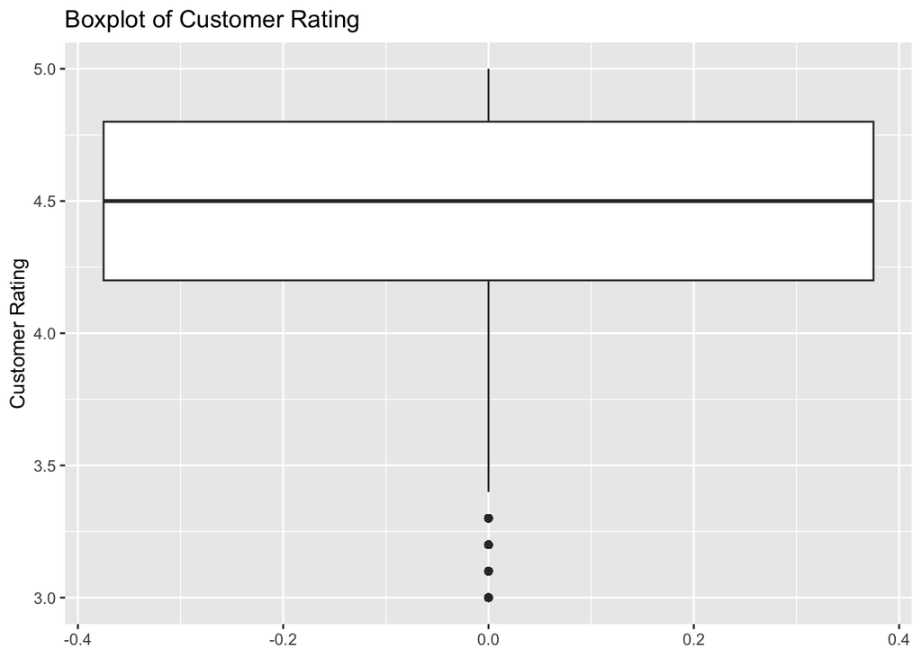

```r
ggplot(df, aes(y = Customer.Rating)) +
  geom_boxplot() +
  labs(title = "Boxplot of Customer Rating", y = "Customer Rating")
```

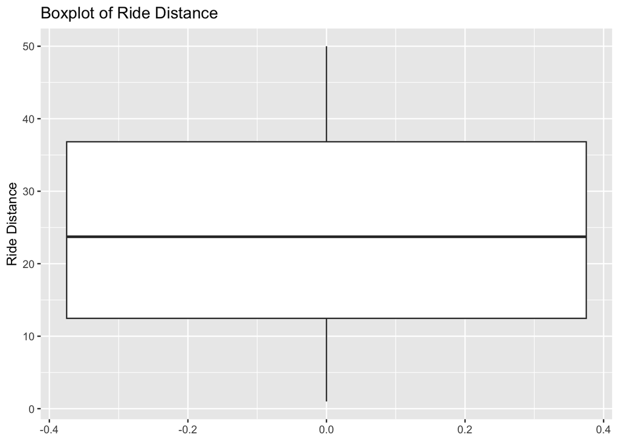

```r
ggplot(df, aes(y = Ride.Distance)) +
  geom_boxplot() +
  labs(title = "Boxplot of Ride Distance", y = "Ride Distance")
```

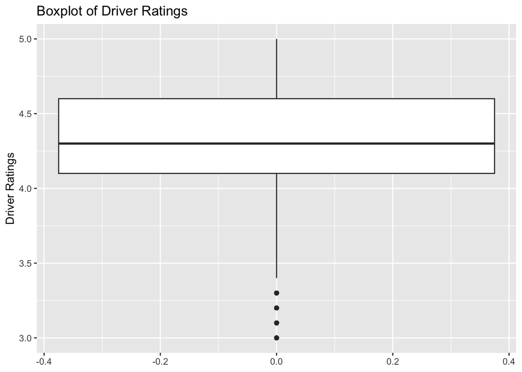

```r
ggplot(df, aes(y = Driver.Ratings)) +
  geom_boxplot() +
  labs(title = "Boxplot of Driver Ratings", y = "Driver Ratings")
```

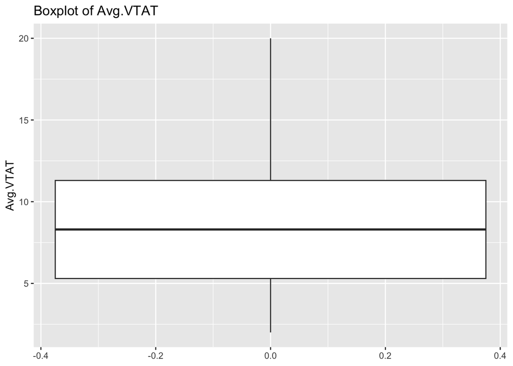

```r
ggplot(df, aes(y = Avg.VTAT)) +
  geom_boxplot() +
  labs(title = "Boxplot of Avg.VTAT", y = "Avg.VTAT")
```

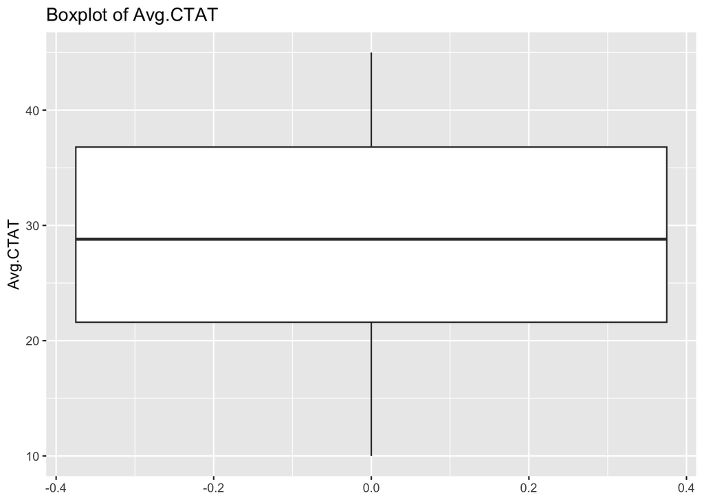

```r
ggplot(df, aes(y = Avg.CTAT)) +
  geom_boxplot() +
  labs(title = "Boxplot of Avg.CTAT", y = "Avg.CTAT")
```

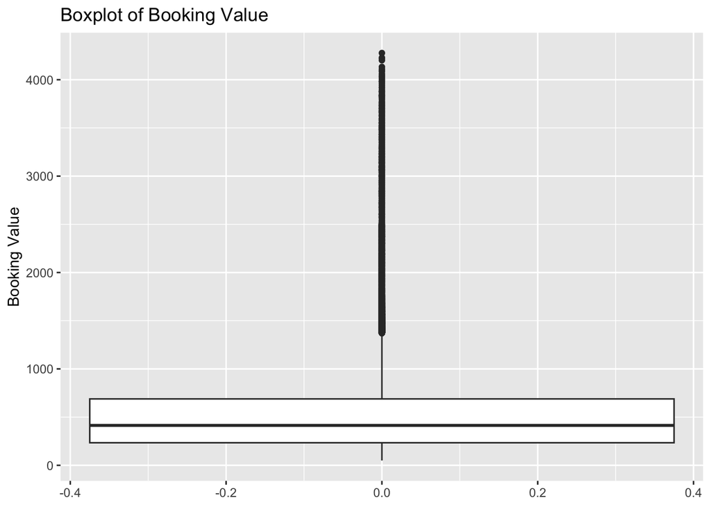

```r
ggplot(df, aes(y = Booking.Value)) +
  geom_boxplot() +
  labs(title = "Boxplot of Booking Value", y = "Booking Value")
```

# Distribution

## Customer Rating

Customer Ratings **strongly skew** **left.**

This means that there are more positive ratings than negative ratings. Little variance.

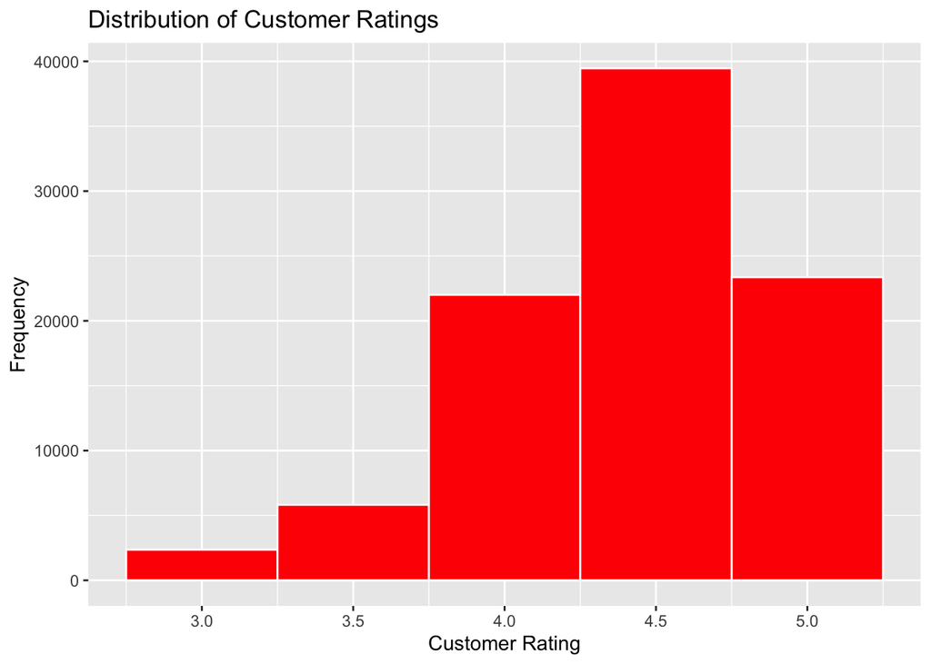

```r
  ggplot(df_clean, aes(x = Customer.Rating)) +
  geom_histogram(binwidth = 0.5, fill = "red", color = "white") +
  labs(title = "Distribution of Customer Ratings",
       x = "Customer Rating",
       y = "Frequency")
```

```r
# Save Graph
# ggsave("customer_rating_histogram.png", plot = p, width = 8, height = 5)
```

## Booking Status Distribution

**Strongly Skewed.** Little Variance.

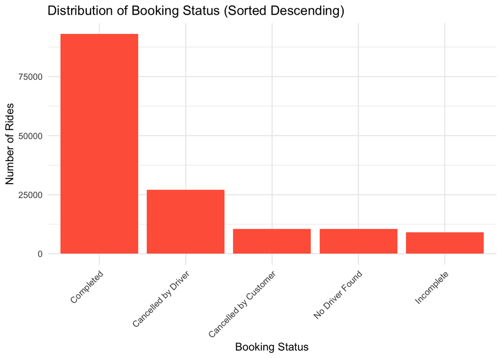

```r
df %>%
  mutate(Booking.Status = fct_infreq(Booking.Status)) %>%   # reorder by frequency
  ggplot(aes(x = Booking.Status)) +
  geom_bar(fill = "tomato") +
  theme_minimal() +
  labs(title = "Distribution of Booking Status (Sorted Descending)",
       x = "Booking Status", y = "Number of Rides") +
  theme(axis.text.x = element_text(angle = 45, hjust = 1))
```

## Driver Ratings Distributions

**Strongly skewed left.**

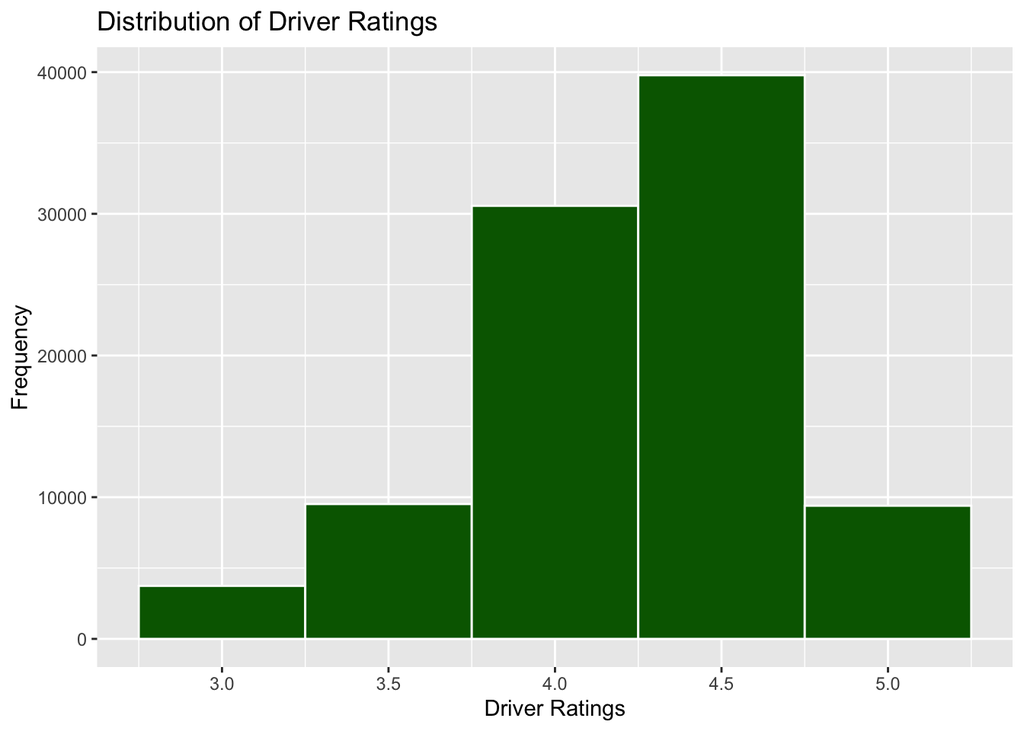

```r
ggplot(df_clean, aes(x = Driver.Ratings)) +
  geom_histogram(binwidth = 0.5, fill = "darkgreen", color = "white") +
  labs(title = "Distribution of Driver Ratings",
       x = "Driver Ratings",
       y = "Frequency")
```

## Booking Value Distribution

**Skewed Right**

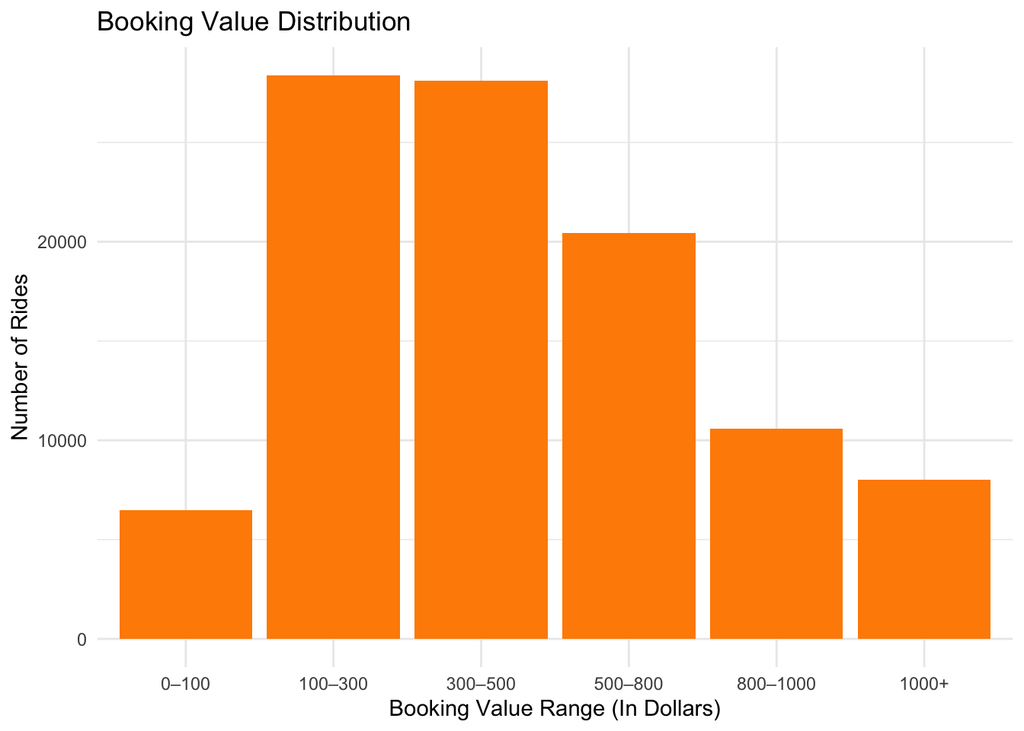

```r
# Create bins for Booking.Value
df <- df %>%
  mutate(ValueBin = cut(Booking.Value,
                        breaks = c(0, 100, 300, 500, 800, 1000, Inf),
                        include.lowest = TRUE,
                        labels = c("0–100", "100–300", "300–500", "500–800", "800–1000", "1000+")))

# Drop missing values
df_no_na <- df %>% filter(!is.na(ValueBin))

# Plot Results as bar
ggplot(df_no_na, aes(x = ValueBin)) +
  geom_bar(fill = "darkorange") +
  theme_minimal() +
  labs(title = "Booking Value Distribution",
       x = "Booking Value Range (In Dollars)", y = "Number of Rides")
```

## Ride Distance Distribution

```r
#ggplot(df, aes(x = Ride.Distance)) +
  #geom_histogram(bins = 30, fill = "darkgreen") +
  #labs(title = "Distribution of Ride Distance")

names(df)
```

```
 [1] "Date"                              "Time"
 [3] "Booking.ID"                        "Booking.Status"
 [5] "Customer.ID"                       "Vehicle.Type"
 [7] "Pickup.Location"                   "Drop.Location"
 [9] "Avg.VTAT"                          "Avg.CTAT"
[11] "Cancelled.Rides.by.Customer"       "Reason.for.cancelling.by.Customer"
[13] "Cancelled.Rides.by.Driver"         "Driver.Cancellation.Reason"
[15] "Incomplete.Rides"                  "Incomplete.Rides.Reason"
[17] "Booking.Value"                     "Ride.Distance"
[19] "Driver.Ratings"                    "Customer.Rating"
[21] "Payment.Method"                    "ValueBin"
```

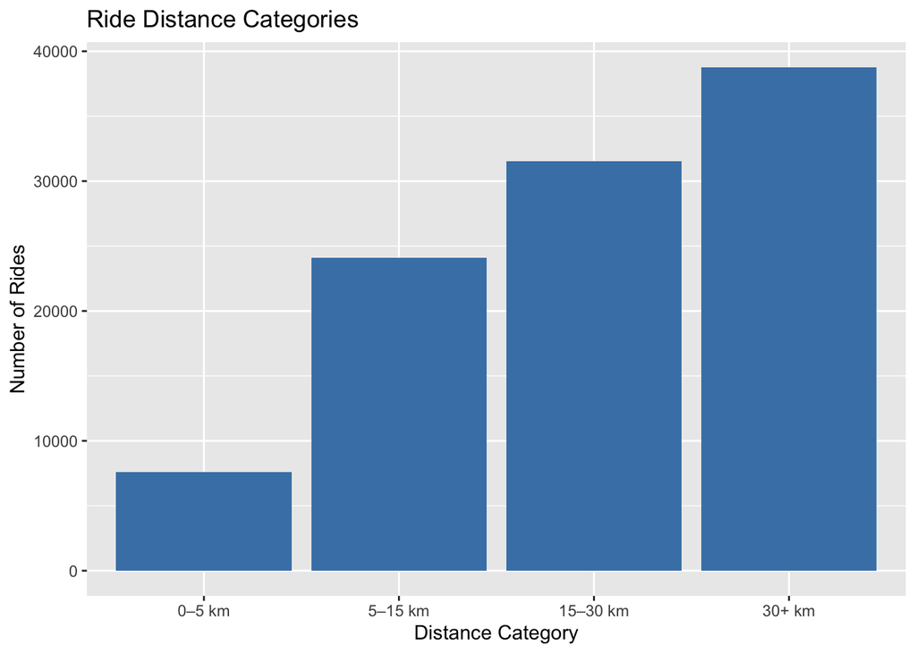

```r
rm(Ride.Distance)

df$RideDistBin <- cut(
  df$Ride.Distance,
  breaks = c(0, 5, 15, 30, Inf),
  labels = c("0–5 km", "5–15 km", "15–30 km", "30+ km"),
  right = FALSE
)

# Drop NA levels
df_binned <- df %>% filter(!is.na(RideDistBin))

ggplot(df_binned, aes(x = RideDistBin)) +
  geom_bar(fill = "steelblue") +
  labs(title = "Ride Distance Categories",
       x = "Distance Category", y = "Number of Rides")
```

## Vehicle Type Distribution

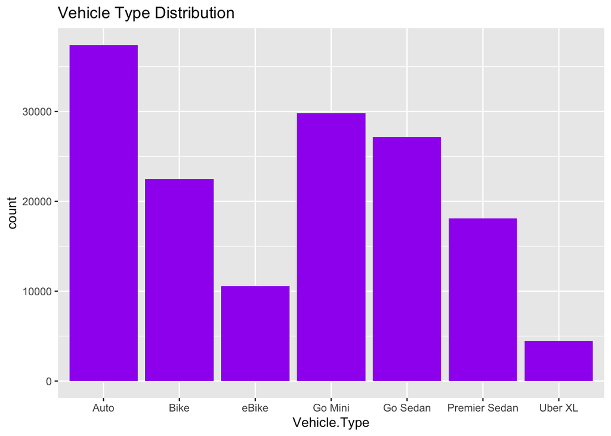

```r
df %>%
  filter(!is.na(Vehicle.Type)) %>%
  ggplot(aes(x = Vehicle.Type)) +
  geom_bar(fill = "purple") +
  labs(title = "Vehicle Type Distribution")
```

# Correlation

## Correlation Analysis

Little to no correlation. There isn’t a significant relationship between Customer.Rating and numeric variables.

```r
numeric_vars <- df_clean %>%
  select(Customer.Rating, Driver.Ratings, Ride.Distance,
         Booking.Value, Avg.VTAT, Avg.CTAT)

cor_matrix <- cor(numeric_vars, use = "complete.obs")
cor_matrix
```

```
                Customer.Rating Driver.Ratings Ride.Distance Booking.Value
Customer.Rating    1.0000000000  -0.0010103511   0.004514477 -0.0002866311
Driver.Ratings    -0.0010103511   1.0000000000  -0.001874531 -0.0002485110
Ride.Distance      0.0045144772  -0.0018745312   1.000000000  0.0056680062
Booking.Value     -0.0002866311  -0.0002485110   0.005668006  1.0000000000
Avg.VTAT          -0.0039453938  -0.0054387866   0.003858046  0.0028231892
Avg.CTAT           0.0009998252   0.0008074932   0.001485855  0.0007396822
                    Avg.VTAT     Avg.CTAT
Customer.Rating -0.003945394 0.0009998252
Driver.Ratings  -0.005438787 0.0008074932
Ride.Distance    0.003858046 0.0014858552
Booking.Value    0.002823189 0.0007396822
Avg.VTAT         1.000000000 0.0015014266
Avg.CTAT         0.001501427 1.0000000000
```

## Spearman Corr Analysis

I used Spearman because Customer.Rating violates normality

```r
numeric_cols <- df_clean[, sapply(df_clean, is.numeric)]
cor(numeric_cols, method = "spearman")
```

```
                    Avg.VTAT     Avg.CTAT Booking.Value Ride.Distance
Avg.VTAT         1.000000000 0.0014972279  0.0059536454   0.003846906
Avg.CTAT         0.001497228 1.0000000000  0.0015302383   0.001488872
Booking.Value    0.005953645 0.0015302383  1.0000000000   0.003820513
Ride.Distance    0.003846906 0.0014888724  0.0038205132   1.000000000
Driver.Ratings  -0.004596251 0.0001130366  0.0008644058  -0.001400084
Customer.Rating -0.003162450 0.0004337621 -0.0040987990   0.004800454
                Driver.Ratings Customer.Rating
Avg.VTAT         -0.0045962515   -0.0031624501
Avg.CTAT          0.0001130366    0.0004337621
Booking.Value     0.0008644058   -0.0040987990
Ride.Distance    -0.0014000843    0.0048004538
Driver.Ratings    1.0000000000   -0.0023968590
Customer.Rating  -0.0023968590    1.0000000000
```

## Booking Status vs Customer Rating

```r
table(df$Booking.Status, !is.na(df$Customer.Rating))
```

```
                        FALSE  TRUE
  Cancelled by Customer 10500     0
  Cancelled by Driver   27000     0
  Completed                 0 93000
  Incomplete             9000     0
  No Driver Found       10500     0
```

```r
table(df_clean$Booking.Status)
```

```
Completed
    93000
```

```r
df$HasRating <- !is.na(df$Customer.Rating)

table(df$Booking.Status, df$HasRating)
```

```
                        FALSE  TRUE
  Cancelled by Customer 10500     0
  Cancelled by Driver   27000     0
  Completed                 0 93000
  Incomplete             9000     0
  No Driver Found       10500     0
```

```r
chisq.test(df$Booking.Status, df$HasRating)
```

```
    Pearson's Chi-squared test

data:  df$Booking.Status and df$HasRating
X-squared = 150000, df = 4, p-value < 2.2e-16
```

## Vehicle Type vs Customer Rating

### Kruskal-Wallis Test

I used this method because Customer.Rating is not normally distributed.

**Result:** There is little relationship between Vehicle Type and Customer Rating.

```r
# Ensure Vehicle.Type is a factor
df_clean$Vehicle.Type <- as.factor(df_clean$Vehicle.Type)

# Kruskal-Wallis test
kruskal.test(Customer.Rating ~ Vehicle.Type, data = df_clean)
```

```
    Kruskal-Wallis rank sum test

data:  Customer.Rating by Vehicle.Type
Kruskal-Wallis chi-squared = 3.5524, df = 6, p-value = 0.737
```

```r
pairwise.wilcox.test(df$Customer.Rating, df$Vehicle.Type,
                     p.adjust.method = "bonferroni")
```

```
    Pairwise comparisons using Wilcoxon rank sum test with continuity correction

data:  df$Customer.Rating and df$Vehicle.Type

              Auto Bike eBike Go Mini Go Sedan Premier Sedan
Bike          1    -    -     -       -        -
eBike         1    1    -     -       -        -
Go Mini       1    1    1     -       -        -
Go Sedan      1    1    1     1       -        -
Premier Sedan 1    1    1     1       1        -
Uber XL       1    1    1     1       1        1

P value adjustment method: bonferroni
```

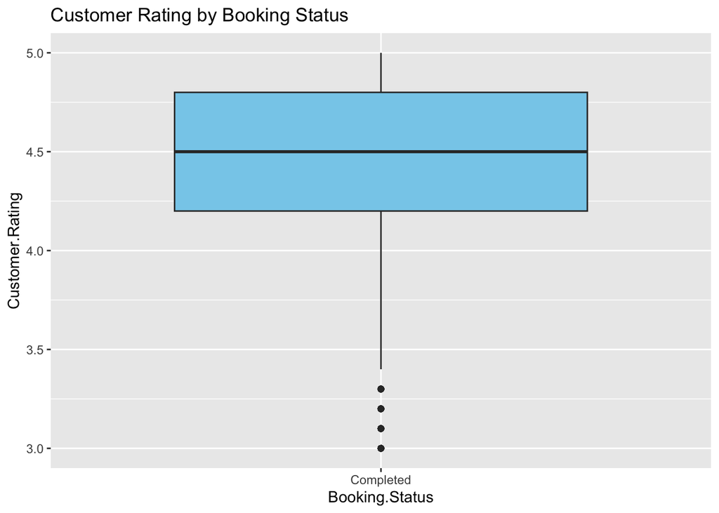

```r
ggplot(df_clean, aes(x = Booking.Status, y = Customer.Rating)) +
  geom_boxplot(fill = "skyblue") +
  labs(title = "Customer Rating by Booking Status")
```

## Linear Regression Model

No significant Linear Regression Model

All the p-values are greater than 0.05.

```r
model <- lm(Customer.Rating ~ Driver.Ratings + Ride.Distance +
            Booking.Value + Avg.VTAT + Avg.CTAT, data = df_clean)

summary(model)
```

```
Call:
lm(formula = Customer.Rating ~ Driver.Ratings + Ride.Distance +
    Booking.Value + Avg.VTAT + Avg.CTAT, data = df_clean)

Residuals:
     Min       1Q   Median       3Q      Max
-1.41108 -0.20572  0.08951  0.38996  0.60236

Coefficients:
                 Estimate Std. Error t value Pr(>|t|)
(Intercept)     4.408e+00  1.555e-02 283.444   <2e-16 ***
Driver.Ratings -1.027e-03  3.286e-03  -0.312    0.755
Ride.Distance   1.434e-04  1.039e-04   1.381    0.167
Booking.Value  -3.339e-07  3.625e-06  -0.092    0.927
Avg.VTAT       -4.636e-04  3.830e-04  -1.210    0.226
Avg.CTAT        5.062e-05  1.660e-04   0.305    0.760
---
Signif. codes:  0 '***' 0.001 '**' 0.01 '*' 0.05 '.' 0.1 ' ' 1

Residual standard error: 0.4378 on 92994 degrees of freedom
Multiple R-squared:  3.822e-05, Adjusted R-squared:  -1.554e-05
F-statistic: 0.7109 on 5 and 92994 DF,  p-value: 0.6151
```

### Residual Plots

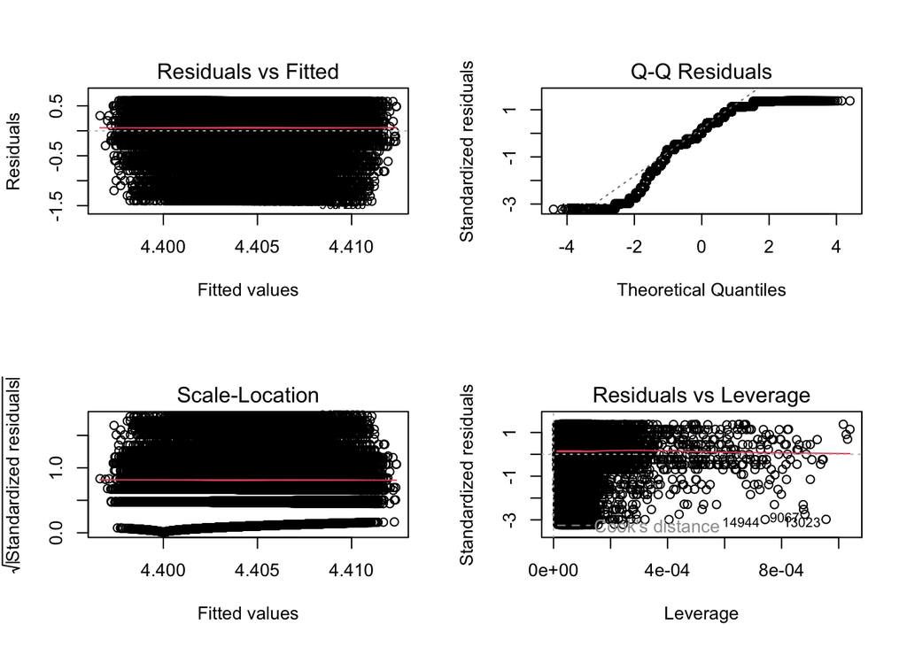

```r
par(mfrow = c(2, 2))
plot(model)
```

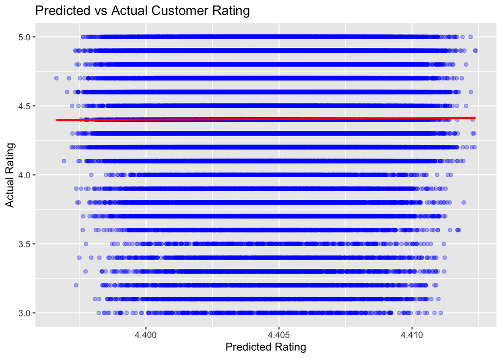

```r
df_clean$predicted <- predict(model)

ggplot(df_clean, aes(x = predicted, y = Customer.Rating)) +
  geom_point(alpha = 0.3, color = "blue") +
  geom_smooth(method = "lm", color = "red") +
  labs(title = "Predicted vs Actual Customer Rating",
       x = "Predicted Rating",
       y = "Actual Rating")
```

[figure not shown]

```r
ggplot(df, aes(x = Vehicle.Type, y = Customer.Rating)) +
  geom_boxplot(fill = "lightblue") +
  labs(title = "Customer Rating by Vehicle Type")
```

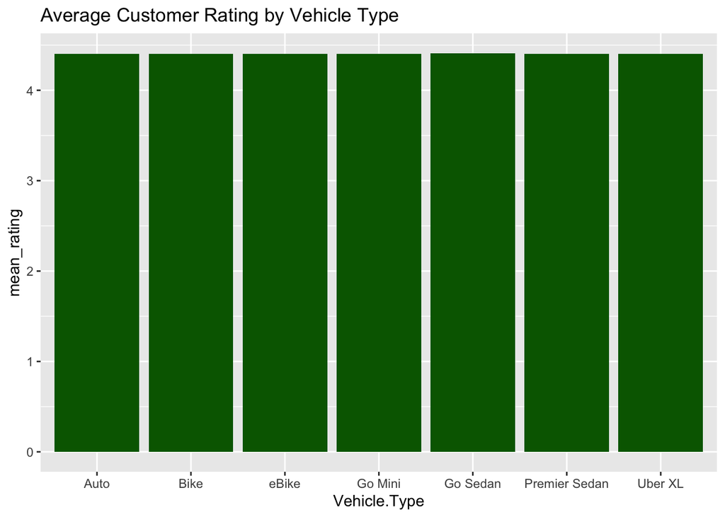

```r
df %>%
  group_by(Vehicle.Type) %>%
  summarize(mean_rating = mean(Customer.Rating, na.rm = TRUE)) %>%
  ggplot(aes(x = Vehicle.Type, y = mean_rating)) +
  geom_col(fill = "darkgreen") +
  labs(title = "Average Customer Rating by Vehicle Type")
```

## Ordinal Logistic Regression

Instead of Linear Regression, I used **Ordinal Logistic Regression**

```r
library(MASS)
df_clean$Customer.Rating <- as.factor(df_clean$Customer.Rating)

model <- polr(Customer.Rating ~ Driver.Ratings + Ride.Distance +
            Booking.Value + Avg.VTAT + Avg.CTAT, data = df_clean, Hess = TRUE)
summary(model)
```

```
Call:
polr(formula = Customer.Rating ~ Driver.Ratings + Ride.Distance +
    Booking.Value + Avg.VTAT + Avg.CTAT, data = df_clean, Hess = TRUE)

Coefficients:
                    Value Std. Error t value
Driver.Ratings -8.469e-03  9.599e-03 -0.8823
Ride.Distance   6.080e-04  4.093e-04  1.4854
Booking.Value  -6.576e-06  1.524e-05 -0.4315
Avg.VTAT       -1.490e-03  1.502e-03 -0.9917
Avg.CTAT        8.182e-05  6.401e-04  0.1278

Intercepts:
        Value     Std. Error t value
3|3.1     -5.3206    0.0063  -841.9704
3.1|3.2   -4.1613    0.0371  -112.2413
3.2|3.3   -3.6835    0.0390   -94.5415
3.3|3.4   -3.3499    0.0397   -84.4440
3.4|3.5   -3.0887    0.0400   -77.1569
3.5|3.6   -2.9830    0.0403   -74.0974
3.6|3.7   -2.7399    0.0404   -67.7555
3.7|3.8   -2.3730    0.0406   -58.4867
3.8|3.9   -2.0915    0.0406   -51.4590
3.9|4     -1.8594    0.0407   -45.6972
4|4.1     -1.7566    0.0407   -43.1464
4.1|4.2   -1.3615    0.0408   -33.4068
4.2|4.3   -0.7667    0.0408   -18.7874
4.3|4.4   -0.2636    0.0409    -6.4516
4.4|4.5   -0.0355    0.0409    -0.8688
4.5|4.6    0.2192    0.0409     5.3554
4.6|4.7    0.7519    0.0410    18.3198
4.7|4.8    1.0588    0.0411    25.7307
4.8|4.9    1.4299    0.0413    34.5979
4.9|5      2.6700    0.0427    62.5463

Residual Deviance: 496799.27
AIC: 496849.27
```